# Part II - How APR and listing category affect loan status

## by Ovy Evbodi

## Investigation Overview

In my analysis, I was interested in exploring how factors like APR, loan amount, listing category and some other factors influence the outcome of a loan status, and what the trend was with borrowers that defaulted in loan payments.

## Dataset Overview

The DataFrame comprises of 113,937 records, with 81 columns including the borrower's occupation, credit grade, loan status and many more. Please take out some time to read through the readme file(if you haven't already done that) to have a better understanding of the columns in this DataFrame.

## Employment status and loan status outcome

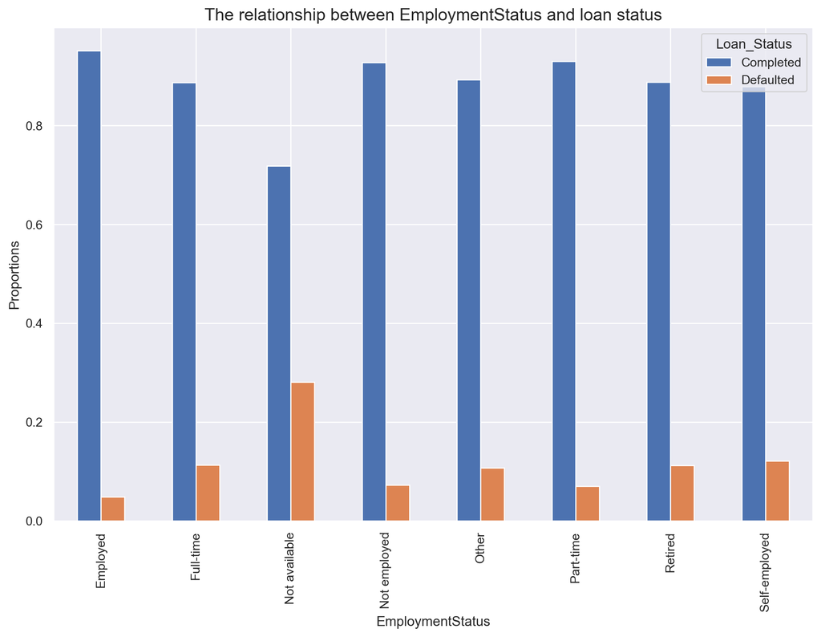

## The relationship between the loan status, APR and listing category

Loans with an APR higher than 0.25 had defaulters, especially the ones taken out for debt consolidation or home improvement.

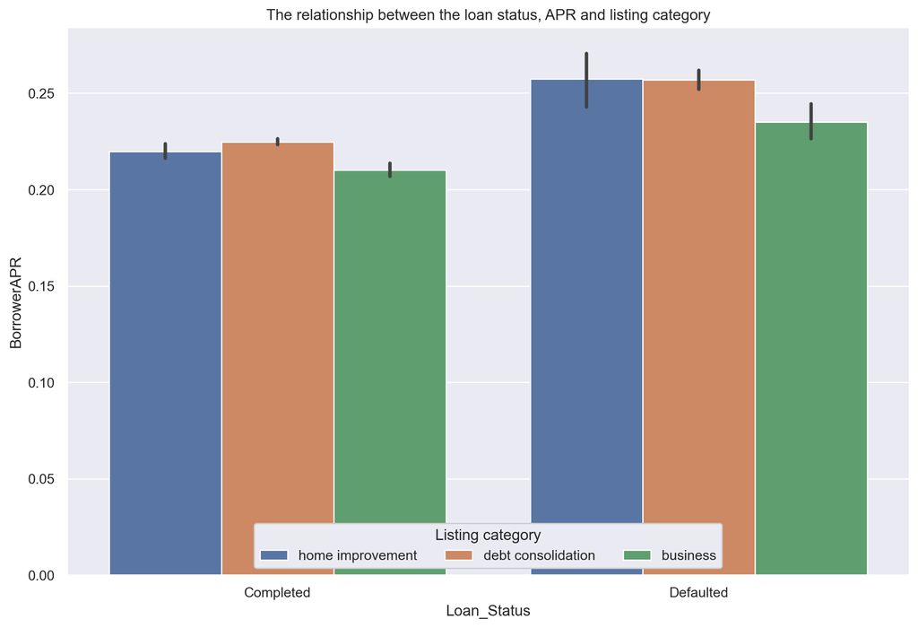

## How the number of recommendations, and the loan amount affect the loan status outcome.

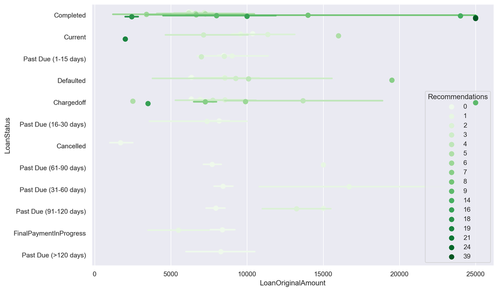